# Final Project

黃淑菱

## 研究主題

星巴克展店位置與地區發展的關係研究

## 研究動機

我們目前取得一份來自Kaggle的全球星巴克分店資料，其中欄位包含城市、國家、經緯度等細項，其中我們很好奇星巴克的分店位置與某地區的特定因素是否存在任何相關性

首先以全球分店的數量排名來看，台灣的分店數量佔星巴克全球分店數量的第八名，對於這個數據我們感到相當震驚，因為台灣只是一個小國，我們很好奇是什麼因素導致這個現象發生?某區域的薪資、房價、產業區位、幸福指數是否有什麼決定性的關鍵，他們在選址時通常會考慮什麼?如果順利，或許能找出下一個潛在適合的新店址

## 研究內容

1.星巴克全球分佈長條圖:跟據此圖發現台灣星巴克數量排名第八名

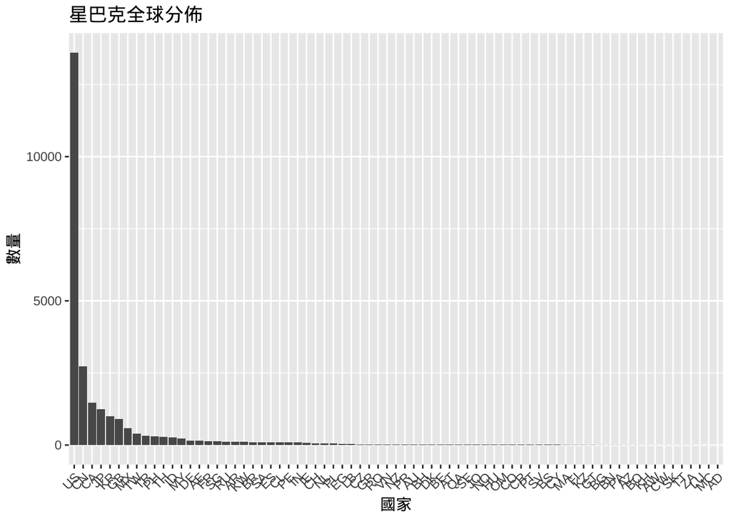

```r
# 讀取資料並使用UTF-8解碼
data <- read.csv("directory.csv")
# 使用dplyr進行計算
country_counts <- data %>%
  group_by(Country) %>%
  summarize(count = n()) %>%
  arrange(desc(count))

## bar chart(世界排名)
ggplot(country_counts, aes(x = reorder(Country, -count), y = count)) +
  geom_bar(stat = "identity") +
  labs(title = "星巴克全球分佈", x = "國家", y = "數量") +
  theme(axis.text.x = element_text(angle = 45, hjust = 1, vjust = 1))
```

2.世界星巴克點狀圖分佈:發現大多存在於已開發國家，同時會避免在內陸、或交通不易到達之處。

```r
library(leaflet)
data = read.csv("directory.csv")
location = select(data,'Longitude','Latitude')

location$Longitude <- as.numeric(location$Longitude)
location$Latitude <- as.numeric(location$Latitude)


#星巴克全球分佈圖
m <- leaflet(location) %>%
  addTiles() %>%
  setView(lng = 20, lat = 10, zoom = 1)
m %>% addCircles
```

[interactive chart not shown]

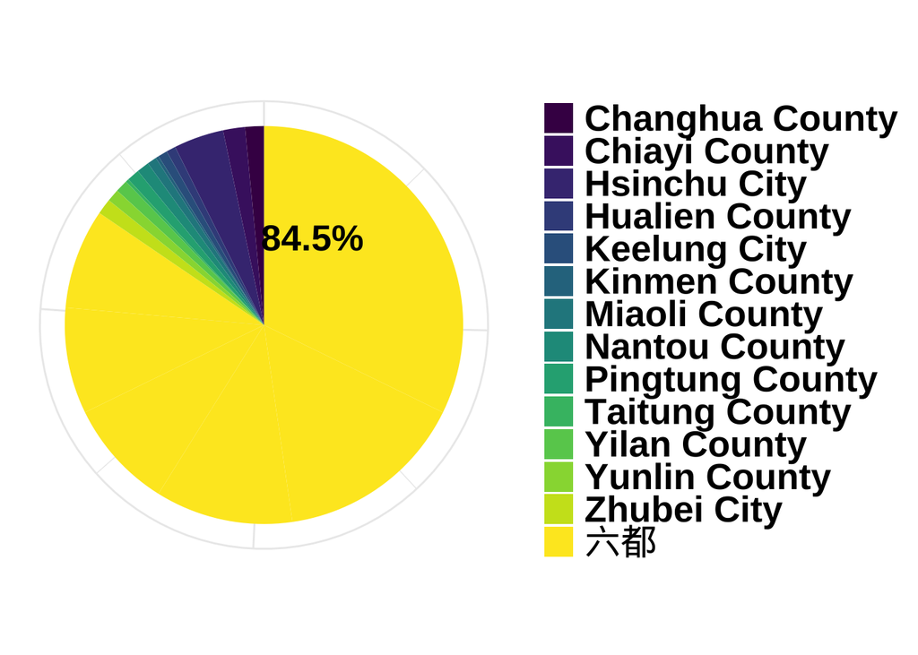

```r
data1 = read.csv("directory1.csv")
TW <- data1 %>% filter(Country == "TW")
data <- data.frame(
  TW_City = c("Taipei City", "New Taipei City", "Taichung City", "Taoyuan City", "Kaohsiung City",
              "Tainan City", "Hsinchu City", "Chiayi County", "Changhua County", "Zhubei City",
              "Nantou County", "Pingtung County", "Yilan County", "Yunlin County", "Hualien County",
              "Keelung City", "Miaoli County", "Kinmen County", "Taitung County"),
  count = c(127, 61, 44, 35, 34, 32, 16, 7, 6, 5, 4, 4, 4, 4, 3, 3, 3, 1, 1)
)

data <- data[order(-data$count), ]

# 將最高的六個城市命名為 "六都"
data$TW_City <- ifelse(rank(-data$count) <= 6, "六都", as.character(data$TW_City))

# 計算六都的百分比
six_cities_percentage <- sum(data$count[data$TW_City == "六都"]) / sum(data$count) * 100

# 建立六都的標記資料
label_data <- data[data$TW_City == "六都", ]
label_data$percentage <- round(six_cities_percentage, 1)

# 建立其他城市的標記資料
other_data <- data[data$TW_City != "六都", ]

# 繪製圓餅圖
ggplot() +
  geom_bar(data = data, aes(x = "", y = count, fill = TW_City), stat = "identity", width = 1) +
  geom_text(data = label_data, aes(x = "", y = count/2, label = ifelse(duplicated(TW_City), "", paste0(percentage, "%"))),
            position = position_stack(vjust = 0.5), color = "black", size = 7, fontface = "bold") +
  scale_fill_viridis_d(alpha = 1, option = "brewer yellow-green-blue", guide = guide_legend(override.aes = list(size = 6))) +
  coord_polar("y", start = 0) +
  labs(x = NULL, y = NULL, fill = NULL) +
  theme_minimal() +
  theme(
    plot.title = element_text(face = "bold", size = 20),
    axis.text = element_blank(),
    axis.title = element_blank(),
    legend.text = element_text(face = "bold", size = 20)
  )
```

4.台灣星巴克點狀圖分佈

```r
data = read.csv("directory.csv")
TW <- data %>% filter(Country == "TW")
TW_location <- select(TW, Longitude, Latitude)
TW_location$Longitude <- as.numeric(TW_location$Longitude)
TW_location$Latitude <- as.numeric(TW_location$Latitude)
m <- leaflet(TW_location) %>%
  addTiles() %>%
  setView(lng = 121, lat = 23.6, zoom = 7)

m %>% addCircles(color = "#000000", fill = "#000000", opacity = 10, radius = 3)
```

[interactive chart not shown]

5.行政區變數比較:星巴克的企業形象給人高貴、舒適的象徵，而金融機構等商務人士相對有更高比例前往咖啡廳辦公、以及從事社交活動，所以一個地區的金融機構數量可能也是星巴克選址的考量。

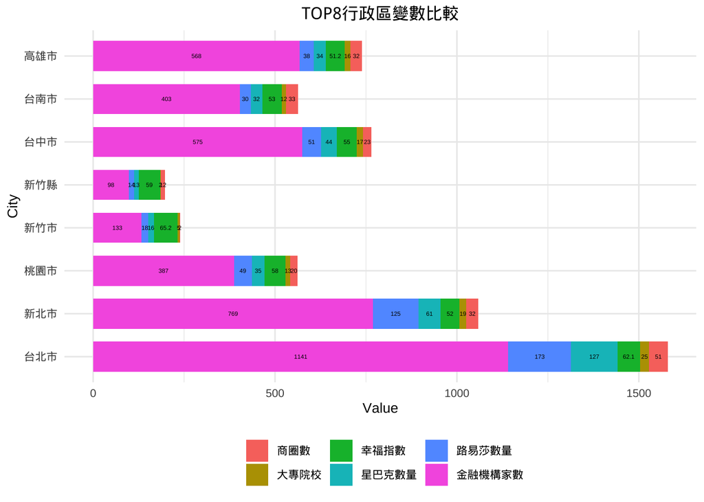

```r
corr_starbucks <- read.csv("相關係數.csv")
corr_starbucks %>%
  pivot_longer(cols = c( "商圈數","幸福指數", "金融機構家數", "大專院校", "路易莎數量", "星巴克數量"), names_to = "Variable", values_to = "Value") %>%
  mutate(City= factor(行政區, levels = unique(行政區))) %>%
  ggplot(aes(x = Value, y = City, fill = Variable)) +
  geom_col(position = "stack", width = 0.7) +
  geom_text(aes(label = round(Value, 1)), position = position_stack(vjust = 0.5), color = "black", size = 1.5) +
  ggtitle("TOP8行政區變數比較") +
  theme_minimal() +
  theme(plot.title = element_text(size = 12, hjust = 0.5),
        axis.title = element_text(size = 10),
        axis.text = element_text(size = 8),
        legend.text = element_text(size = 8),
        legend.title = element_blank(),
        legend.position = "bottom")
```

[figure not shown]

```r
corr_starbucks= read.csv("相關係數.csv")
corr_starbucks <- corr_starbucks[,-1 ]

correlation <- cor(as.matrix(corr_starbucks))

invisible(round(correlation, 3))
corrplot(corr=correlation,sig.level=0.03,
         method = "color",type="upper",addCoef.col="black"
           ,tl.col="black",family='wqy-microhei')
```

7.工業區位與星巴克分佈的關係(地圖黑色區塊是台灣各個工業區之範圍): 工業區分成高科技與傳產，傳產工業區與星巴克位置沒有絕對關係，因為人流週期性太分明，但高科技園區附近則相較有更多的店面以及消費力，星巴克數量也較多。

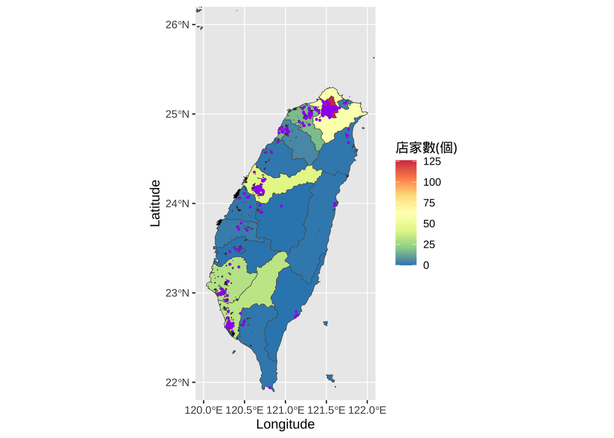

```r
starbucks = read.csv("directory.csv")
TW <-starbucks  %>% filter(Country == "TW")
TW_location=select(TW,'Longitude','Latitude')
TW_location$Longitude=as.numeric(TW_location$Longitude)
TW_location$Latitude=as.numeric(TW_location$Latitude)

TW_City_counts <- TW %>%
  group_by(TW$City) %>%
  summarize(count = n())%>%
  arrange(desc(count))


# 使用gsub函数将英文替换为中文
TW_City_counts$`TW$City` <- gsub("New Taipei City", "新北市", TW_City_counts$`TW$City`)
TW_City_counts$`TW$City` <- gsub("Taipei City", "台北市", TW_City_counts$`TW$City`)
TW_City_counts$`TW$City` <- gsub("Taichung City", "台中", TW_City_counts$`TW$City`)
TW_City_counts$`TW$City` <- gsub("Taoyuan City", "桃園市", TW_City_counts$`TW$City`)
TW_City_counts$`TW$City` <- gsub("Kaohsiung City", "高雄市", TW_City_counts$`TW$City`)
TW_City_counts$`TW$City` <- gsub("Tainan City", "台南", TW_City_counts$`TW$City`)
TW_City_counts$`TW$City` <- gsub("Hsinchu City", "新竹市", TW_City_counts$`TW$City`)
TW_City_counts$`TW$City` <- gsub("Chiayi County", "嘉義縣", TW_City_counts$`TW$City`)
TW_City_counts$`TW$City` <- gsub("Zhubei City", "新竹縣", TW_City_counts$`TW$City`)
TW_City_counts$`TW$City` <- gsub("Nantou County", "南投縣", TW_City_counts$`TW$City`)
TW_City_counts$`TW$City` <- gsub("Pingtung County", "屏東縣", TW_City_counts$`TW$City`)
TW_City_counts$`TW$City` <- gsub("Yilan County", "宜蘭縣", TW_City_counts$`TW$City`)
TW_City_counts$`TW$City` <- gsub("Yunlin County", "雲林縣", TW_City_counts$`TW$City`)
TW_City_counts$`TW$City` <- gsub("Changhua County", "彰化縣", TW_City_counts$`TW$City`)
TW_City_counts$`TW$City` <- gsub("Hualien County", "花蓮縣", TW_City_counts$`TW$City`)
TW_City_counts$`TW$City` <- gsub("Keelung City", "基隆市", TW_City_counts$`TW$City`)
TW_City_counts$`TW$City` <- gsub("Miaoli County", "苗栗縣", TW_City_counts$`TW$City`)
TW_City_counts$`TW$City` <- gsub("Kinmen County", "金門縣", TW_City_counts$`TW$City`)
TW_City_counts$`TW$City` <- gsub("Taitung County", "台東縣", TW_City_counts$`TW$City`)


taiwan.map=st_read("gadm36_TWN_2.shp",quiet = TRUE)
my.taiwan.map <- taiwan.map[c("NL_NAME_2", "geometry")]
my.taiwan.map$NL_NAME_2E <- as.character(my.taiwan.map$NL_NAME_2)
my.taiwan.map.data <- left_join(my.taiwan.map, TW_City_counts,
                                by= c("NL_NAME_2" = "TW$City"))

work.map=st_read("2022工業區範圍.shp",quiet = TRUE)
work.area <- work.map[c("名稱", "geometry")]
work.area$名稱<- as.character(work.area$名稱)


my.taiwan.map.data$count[is.na(my.taiwan.map.data$count)] = 0

ggplot()+
  geom_sf(data = my.taiwan.map.data, aes(fill = `count`)) +
  scale_fill_distiller(palette = "Spectral", name = "店家數(個)") +
  geom_point(data = TW_location, aes(x = Longitude, y = Latitude), color = "purple", size = 0.5) +
  geom_sf(data = work.area, fill = "black") +
  coord_sf(xlim = c(120, 122), ylim = c(22, 26))
```

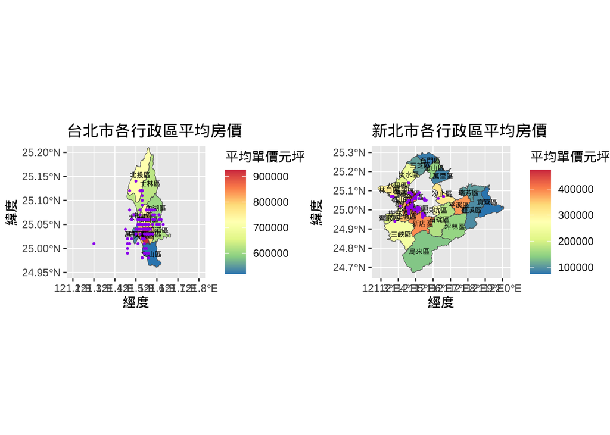

```r
Taipei = read.csv("Taipei_lvr_land_A_109111.csv")
Taipei = Taipei[,which(colnames(Taipei)%in% c('鄉鎮市區','交易標的','單價元平方公尺'))]
Taipei = Taipei[-1,]
Taipei = Taipei[!is.na(Taipei$`單價元平方公尺`) & Taipei$`單價元平方公尺` != "", ]
Taipei = Taipei[!(Taipei$`交易標的` == "土地") , ]
Taipei$單價元平方公尺= sapply(Taipei$單價元平方公尺,function(x)as.integer(x))
Taipei$`單價元坪` = Taipei$`單價元平方公尺` / 0.3025

# 按鄉鎮市區分組，計算平均值
average_df <- Taipei %>%
  group_by(鄉鎮市區) %>%
  summarise(平均價格 = mean(`單價元坪`, na.rm = TRUE))

Taiwan=st_read("/Users/user/Desktop/星巴克/Taiwan/TOWN_MOI_1120317.shp",quiet = TRUE)

Taipei.map = Taiwan[Taiwan$COUNTYNAME == "臺北市",]

Taipei.map$TOWNNAME <- as.character(Taipei.map$TOWNNAME)

Taipei.map.data=left_join(Taipei.map,average_df,by= c("TOWNNAME"= "鄉鎮市區"))
Taipei.map.data$`平均價格`[is.na(Taipei.map.data$`平均價格`) | Taipei.map.data$`平均價格` == ""] = 0

starbucks = read.csv("directory.csv")
TW <-starbucks  %>% filter(Country == "TW")
TW_location=select(TW,'Longitude','Latitude')
TW_location$Longitude=as.numeric(TW_location$Longitude)
TW_location$Latitude=as.numeric(TW_location$Latitude)
Taipei_location = TW[TW$City == "Taipei City",]



# 将点标记数据转换为sf对象
Taipei_location_sf <- st_as_sf(Taipei_location, coords = c("Longitude", "Latitude"))

# 设置点标记数据的坐标参考系为WGS84（EPSG:4326）
st_crs(Taipei_location_sf) <- st_crs(4326)

# 将地理空间数据和点标记数据转换为相同的坐标参考系
Taipei.map.data <- st_transform(Taipei.map.data, crs = st_crs(Taipei_location_sf))
options(scipen = 100)
plot1=ggplot() +
  geom_sf(data = Taipei.map.data, aes(fill = 平均價格)) +
  geom_sf_text(data = Taipei.map.data, aes(label = TOWNNAME), size = 2) +
  geom_sf(data = Taipei_location_sf, color = "purple", size = 0.5) +
  scale_fill_distiller(palette = "Spectral", name = "平均單價元坪") +
  labs(title = "台北市各行政區平均房價", x = "經度", y = "緯度")+
  coord_sf(xlim = c(121.2, 121.8), ylim = c(24.95, 25.2))



NewTaipeiCity = read.csv("NewTaipeiCity_lvr_land_A_105111.csv")


NewTaipeiCity = NewTaipeiCity[,which(colnames(NewTaipeiCity)%in% c('鄉鎮市區','交易標的','單價元平方公尺'))]
NewTaipeiCity = NewTaipeiCity[-1,]
NewTaipeiCity = NewTaipeiCity[!is.na(NewTaipeiCity$`單價元平方公尺`) & NewTaipeiCity$`單價元平方公尺` != "", ]
NewTaipeiCity = NewTaipeiCity[!(NewTaipeiCity$`交易標的` == "土地") , ]
NewTaipeiCity$單價元平方公尺= sapply(NewTaipeiCity$單價元平方公尺,function(x)as.integer(x))
NewTaipeiCity$`單價元坪` = NewTaipeiCity$`單價元平方公尺` / 0.3025


# 按鄉鎮市區分組，計算平均值
average_df <- NewTaipeiCity %>%
  group_by(`鄉鎮市區`) %>%
  summarise(平均價格 = mean(`單價元坪`, na.rm = TRUE))




Taiwan=st_read("/Users/user/Desktop/星巴克/Taiwan/TOWN_MOI_1120317.shp",quiet = TRUE)

NewTaipeiCity.map = Taiwan[Taiwan$COUNTYNAME == "新北市",]
NewTaipeiCity.map$TOWNNAME <- as.character(NewTaipeiCity.map$TOWNNAME)
NewTaipeiCity.map.data=left_join(NewTaipeiCity.map,average_df,by= c("TOWNNAME"= "鄉鎮市區"))
NewTaipeiCity.map.data$`平均價格`[is.na(NewTaipeiCity.map.data$`平均價格`) |NewTaipeiCity.map.data$`平均價格` == ""] = 0


NewTaipeiCity_location = TW[TW$City == "New Taipei City",]


# 将点标记数据转换为sf对象
NewTaipeiCity_location_sf <- st_as_sf(NewTaipeiCity_location, coords = c("Longitude", "Latitude"))

# 设置点标记数据的坐标参考系为WGS84（EPSG:4326）
st_crs(NewTaipeiCity_location_sf) <- st_crs(4326)

# 将地理空间数据和点标记数据转换为相同的坐标参考系
NewTaipeiCity.map.data <- st_transform(NewTaipeiCity.map.data, crs = st_crs(NewTaipeiCity_location_sf))

# 绘制地理空间数据和点标记数据的地图

options(scipen = 999)
suppressWarnings({
  plot1=ggplot() +
  geom_sf(data = Taipei.map.data, aes(fill = 平均價格)) +
  geom_sf_text(data = Taipei.map.data, aes(label = TOWNNAME), size = 2) +
  geom_sf(data = Taipei_location_sf, color = "purple", size = 0.5) +
  scale_fill_distiller(palette = "Spectral", name = "平均單價元坪") +
  labs(title = "台北市各行政區平均房價", x = "經度", y = "緯度")+
  coord_sf(xlim = c(121.2, 121.8), ylim = c(24.95, 25.2))

  plot2=ggplot() +
  geom_sf(data = NewTaipeiCity.map.data, aes(fill = 平均價格)) +
  geom_sf_text(data = NewTaipeiCity.map.data, aes(label = TOWNNAME), size = 2) +
  geom_sf(data = NewTaipeiCity_location_sf, color = "purple", size = 0.5) +
  scale_fill_distiller(palette = "Spectral", name = "平均單價元坪") +
  labs(title = "新北市各行政區平均房價", x = "經度", y = "緯度")
  combined_plot <- plot_grid(plot1, plot2, ncol = 2, align = "hv")
  combined_plot })
```

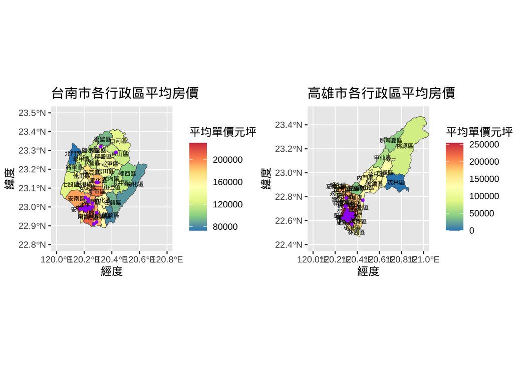

```r
Tainan = read.csv("Tainan_lvr_land_A_109111.csv")
Tainan = Tainan [,which(colnames(Tainan)%in% c('鄉鎮市區','交易標的','單價元平方公尺'))]
Tainan = Tainan[-1,]
Tainan = Tainan[!is.na(Tainan$`單價元平方公尺`) & Tainan$`單價元平方公尺` != "", ]
Tainan = Tainan[!(Tainan$`交易標的` == "土地") , ]
Tainan$單價元平方公尺= sapply(Tainan$單價元平方公尺,function(x)as.integer(x))
Tainan$`單價元坪` = Tainan$`單價元平方公尺` / 0.3025

# 按鄉鎮市區分組，計算平均值
average_df <- Tainan %>%
  group_by(鄉鎮市區) %>%
  summarise(平均價格 = mean(`單價元坪`, na.rm = TRUE))

Tainan.map = Taiwan[Taiwan$COUNTYNAME == "臺南市",]

Tainan.map$TOWNNAME <- as.character(Tainan.map$TOWNNAME)

Tainan.map.data=left_join(Tainan.map,average_df,by= c("TOWNNAME"= "鄉鎮市區"))
Tainan.map.data$`平均價格`[is.na(Tainan.map.data$`平均價格`) | Tainan.map.data$`平均價格` == ""] = 0


Tainan_location = TW[TW$City == "Tainan City",]


Tainan_location_sf <- st_as_sf(Tainan_location, coords = c("Longitude", "Latitude"))

# 设置点标记数据的坐标参考系为WGS84（EPSG:4326）
st_crs(Tainan_location_sf) <- st_crs(4326)

# 将地理空间数据和点标记数据转换为相同的坐标参考系
Tainan.map.data <- st_transform(Tainan.map.data, crs = st_crs(Tainan_location_sf))

# 绘制地理空间数据和点标记数据的地图
plot3=ggplot() +
  geom_sf(data = Tainan.map.data, aes(fill = 平均價格)) +
  geom_sf_text(data = Tainan.map.data, aes(label = TOWNNAME), size = 2) +
  geom_sf(data = Tainan_location_sf, color = "purple", size = 1) +
  scale_fill_distiller(palette = "Spectral", name = "平均單價元坪") +
  labs(title = "台南市各行政區平均房價", x = "經度", y = "緯度")+
  coord_sf(xlim = c(120, 120.8), ylim = c(22.8, 23.5))




Kaohsiung = read.csv("Kaohsiung_lvr_land_A_109111.csv")
Kaohsiung = Kaohsiung[,which(colnames(Kaohsiung)%in% c('鄉鎮市區','交易標的','單價元平方公尺'))]
Kaohsiung = Kaohsiung[-1,]
Kaohsiung = Kaohsiung[!is.na(Kaohsiung$`單價元平方公尺`) & Kaohsiung$`單價元平方公尺` != "", ]
Kaohsiung = Kaohsiung[!(Kaohsiung$`交易標的` == "土地") , ]
Kaohsiung$單價元平方公尺= sapply(Kaohsiung$單價元平方公尺,function(x)as.integer(x))
Kaohsiung$`單價元坪` = Kaohsiung$`單價元平方公尺` / 0.3025


# 按鄉鎮市區分組，計算平均值
average_df <- Kaohsiung %>%
  group_by(鄉鎮市區) %>%
  summarise(平均價格 = mean(`單價元坪`, na.rm = TRUE))

Taiwan=st_read("/Users/user/Desktop/星巴克/Taiwan/TOWN_MOI_1120317.shp",quiet = TRUE)
Kaohsiung.map = Taiwan[Taiwan$COUNTYNAME == "高雄市",]
Kaohsiung.map$TOWNNAME <- as.character(Kaohsiung.map$TOWNNAME)
Kaohsiung.map.data=left_join(Kaohsiung.map,average_df,by= c("TOWNNAME"= "鄉鎮市區"))
Kaohsiung.map.data$`平均價格`[is.na(Kaohsiung.map.data$`平均價格`) |Kaohsiung.map.data$`平均價格` == ""] = 0

Kaohsiung_location = TW[TW$City == "Kaohsiung City",]
Kaohsiung_location_sf <- st_as_sf(Kaohsiung_location, coords = c("Longitude", "Latitude"))
st_crs(Kaohsiung_location_sf) <- st_crs(4326)
Kaohsiung.map.data <- st_transform(Kaohsiung.map.data, crs = st_crs(Kaohsiung_location_sf))
suppressWarnings({
  plot3=ggplot() +
  geom_sf(data = Tainan.map.data, aes(fill = 平均價格)) +
  geom_sf_text(data = Tainan.map.data, aes(label = TOWNNAME), size = 2) +
  geom_sf(data = Tainan_location_sf, color = "purple", size = 1) +
  scale_fill_distiller(palette = "Spectral", name = "平均單價元坪") +
  labs(title = "台南市各行政區平均房價", x = "經度", y = "緯度")+
  coord_sf(xlim = c(120, 120.8), ylim = c(22.8, 23.5))

  plot4=ggplot() +
  geom_sf(data = Kaohsiung.map.data, aes(fill = 平均價格)) +
  geom_sf_text(data = Kaohsiung.map.data, aes(label = TOWNNAME), size = 2) +
  geom_sf(data = Kaohsiung_location_sf, color = "purple", size = 1) +
  scale_fill_distiller(palette = "Spectral", name = "平均單價元坪") +
  labs(title = "高雄市各行政區平均房價", x = "經度", y = "緯度")+
  coord_sf(xlim = c(120, 121), ylim = c(22.4, 23.5))
  combined_plot <- plot_grid(plot3, plot4, ncol = 2, align = "hv")
  combined_plot})
```

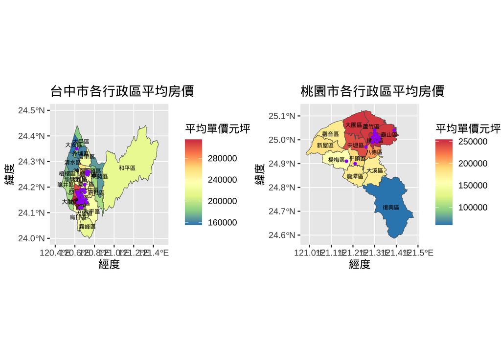

```r
Taichung = read.csv("Taichung_lvr_land_A_109111.csv")
Taichung = Taichung[,which(colnames(Taichung)%in% c('鄉鎮市區','交易標的','單價元平方公尺'))]
Taichung = Taichung[-1,]
Taichung = Taichung[!is.na(Taichung$`單價元平方公尺`) & Taichung$`單價元平方公尺` != "", ]
Taichung = Taichung[!(Taichung$`交易標的` == "土地") , ]
Taichung$單價元平方公尺= sapply(Taichung$單價元平方公尺,function(x)as.integer(x))
Taichung$`單價元坪` = Taichung$`單價元平方公尺` / 0.3025

# 按鄉鎮市區分組，計算平均值
average_df <- Taichung %>%
  group_by(鄉鎮市區) %>%
  summarise(平均價格 = mean(`單價元坪`, na.rm = TRUE))



Taichung.map = Taiwan[Taiwan$COUNTYNAME == "臺中市",]

Taichung.map$TOWNNAME <- as.character(Taichung.map$TOWNNAME)

Taichung.map.data=left_join(Taichung.map,average_df,by= c("TOWNNAME"= "鄉鎮市區"))
Taichung.map.data$`平均價格`[is.na(Taichung.map.data$`平均價格`) | Taichung.map.data$`平均價格` == ""] = 0


Taichung_location = TW[TW$City == "Taichung City",]


# 将点标记数据转换为sf对象
Taichung_location_sf <- st_as_sf(Taichung_location, coords = c("Longitude", "Latitude"))

# 设置点标记数据的坐标参考系为WGS84（EPSG:4326）
st_crs(Taichung_location_sf) <- st_crs(4326)

# 将地理空间数据和点标记数据转换为相同的坐标参考系
Taichung.map.data <- st_transform(Taichung.map.data, crs = st_crs(Taichung_location_sf))

# 绘制地理空间数据和点标记数据的地图
plot5=ggplot() +
  geom_sf(data = Taichung.map.data, aes(fill = 平均價格)) +
  geom_sf_text(data = Taichung.map.data, aes(label = TOWNNAME), size = 2) +
  geom_sf(data = Taichung_location_sf, color = "purple", size = 1) +
  scale_fill_distiller(palette = "Spectral", name = "平均單價元坪") +
  labs(title = "台中市各行政區平均房價", x = "經度", y = "緯度")+
  coord_sf(xlim = c(120.4, 121.5), ylim = c(24, 24.5))

Taoyuan = read.csv("Taoyuan_lvr_land_A_109111.csv")
Taoyuan = Taoyuan [,which(colnames(Taoyuan)%in% c('鄉鎮市區','交易標的','單價元平方公尺'))]
Taoyuan = Taoyuan[-1,]
Taoyuan = Taoyuan[!is.na(Taoyuan$`單價元平方公尺`) & Taoyuan$`單價元平方公尺` != "", ]
Taoyuan = Taoyuan[!(Taoyuan$`交易標的` == "土地") , ]
Taoyuan$單價元平方公尺= sapply(Taoyuan$單價元平方公尺,function(x)as.integer(x))
Taoyuan$`單價元坪` = Taoyuan$`單價元平方公尺` / 0.3025


# 按鄉鎮市區分組，計算平均值
average_df <- Taoyuan %>%
  group_by(鄉鎮市區) %>%
  summarise(平均價格 = mean(`單價元坪`, na.rm = TRUE))


Taoyuan.map = Taiwan[Taiwan$COUNTYNAME == "桃園市",]
Taoyuan.map$TOWNNAME <- as.character(Taoyuan.map$TOWNNAME)

Taoyuan.map.data=left_join(Taoyuan.map,average_df,by= c("TOWNNAME"= "鄉鎮市區"))
Taoyuan.map.data$`平均價格`[is.na(Taoyuan.map.data$`平均價格`) | Taoyuan.map.data$`平均價格` == ""] = 0


starbucks = read.csv("directory.csv")
TW <-starbucks  %>% filter(Country == "TW")
TW_location=select(TW,'Longitude','Latitude')
TW_location$Longitude=as.numeric(TW_location$Longitude)
TW_location$Latitude=as.numeric(TW_location$Latitude)
Taoyuan_location = TW[TW$City == "Taoyuan City",]


# 将点标记数据转换为sf对象
Taoyuan_location_sf <- st_as_sf(Taoyuan_location, coords = c("Longitude", "Latitude"))

# 设置点标记数据的坐标参考系为WGS84（EPSG:4326）
st_crs(Taoyuan_location_sf) <- st_crs(4326)

# 将地理空间数据和点标记数据转换为相同的坐标参考系
Taoyuan.map.data <- st_transform(Taoyuan.map.data, crs = st_crs(Taoyuan_location_sf))
suppressWarnings({
  plot6=ggplot() +
  geom_sf(data = Taoyuan.map.data, aes(fill = 平均價格)) +
  geom_sf_text(data = Taoyuan.map.data, aes(label = TOWNNAME), size = 2) +
  geom_sf(data = Taoyuan_location_sf, color = "purple", size = 1) +
  scale_fill_distiller(palette = "Spectral", name = "平均單價元坪") +
  labs(title = "桃園市各行政區平均房價", x = "經度", y = "緯度")

  plot5=ggplot() +
  geom_sf(data = Taichung.map.data, aes(fill = 平均價格)) +
  geom_sf_text(data = Taichung.map.data, aes(label = TOWNNAME), size = 2) +
  geom_sf(data = Taichung_location_sf, color = "purple", size = 1) +
  scale_fill_distiller(palette = "Spectral", name = "平均單價元坪") +
  labs(title = "台中市各行政區平均房價", x = "經度", y = "緯度")+
  coord_sf(xlim = c(120.4, 121.5), ylim = c(24, 24.5))

  combined_plot <- plot_grid(plot5, plot6, ncol = 2, align = "hv")
# Display the combined plot
  combined_plot})
```

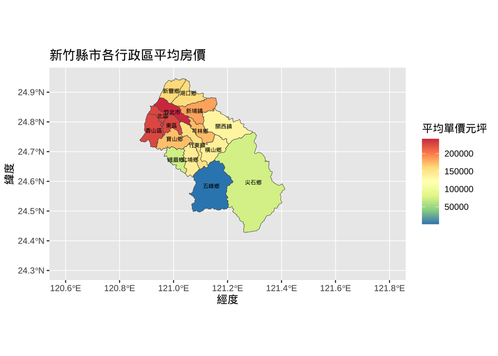

```r
Taiwan =st_read("/Users/user/Desktop/星巴克/Taiwan/TOWN_MOI_1120317.shp",quiet = TRUE)
TW=st_read("gadm36_TWN_2.shp",quiet = TRUE)
HsinchuCity <- read.csv("HsinchuCity.csv")

HsinchuCity = HsinchuCity [,which(colnames(HsinchuCity)%in% c('鄉鎮市區','交易標的','單價元平方公尺'))]
HsinchuCity = HsinchuCity[-1,]
HsinchuCity = HsinchuCity[!is.na(HsinchuCity$`單價元平方公尺`) & HsinchuCity$`單價元平方公尺` != "", ]
HsinchuCity = HsinchuCity[!(HsinchuCity$`交易標的` == "土地") , ]

HsinchuCity$單價元平方公尺= sapply(HsinchuCity$單價元平方公尺,function(x)as.integer(x))

HsinchuCity$`單價元坪` = HsinchuCity$`單價元平方公尺` / 0.3025

# 按鄉鎮市區分組，計算平均值
average_df <- HsinchuCity %>%
  group_by(鄉鎮市區) %>%
  summarise(平均價格 = mean(`單價元坪`, na.rm = TRUE))


center_price=average_df$平均價格[average_df$鄉鎮市區 == "新竹市"]


Hsinchu = Taiwan[Taiwan$COUNTYNAME == "新竹市"| Taiwan$COUNTYNAME == "新竹縣",]
Hsinchu.map=Hsinchu [c("TOWNNAME", "geometry")]
Hsinchu.map$TOWNNAME <- as.character(Hsinchu.map$TOWNNAME)

HsinchuCity.map.data=left_join(Hsinchu.map,average_df,by= c("TOWNNAME"= "鄉鎮市區"))
HsinchuCity.map.data$平均價格[HsinchuCity.map.data$TOWNNAME == "北區"] = center_price
HsinchuCity.map.data$平均價格[HsinchuCity.map.data$TOWNNAME == "香山區"]= center_price
HsinchuCity.map.data$平均價格[HsinchuCity.map.data$TOWNNAME == "東區"]= center_price

HsinchuCity_location = TW[TW$City == "Hsinchu City",]


# 将点标记数据转换为sf对象
HsinchuCity_location_sf <- st_as_sf(HsinchuCity_location, coords = c("Longitude", "Latitude"))

# 设置点标记数据的坐标参考系为WGS84（EPSG:4326）
st_crs(HsinchuCity_location_sf) <- st_crs(4326)

# 将地理空间数据和点标记数据转换为相同的坐标参考系
HsinchuCity.map.data <- st_transform(HsinchuCity.map.data, crs = st_crs(HsinchuCity_location_sf))



# 绘制地理空间数据和点标记数据的地图
ggplot() +
  geom_sf(data = HsinchuCity.map.data, aes(fill = 平均價格)) +
  geom_sf_text(data = HsinchuCity.map.data, aes(label = TOWNNAME), size = 2) +
  geom_sf(data = HsinchuCity_location_sf, color = "purple", size = 1) +
  scale_fill_distiller(palette = "Spectral", name = "平均單價元坪") +
  labs(title = "新竹縣市各行政區平均房價", x = "經度", y = "緯度")+
  coord_sf(xlim = c(120.6, 121.8), ylim = c(24.3, 24.95))
```

## 問題討論

- 問題1 Where did you get your project ideas?

  星巴克一直是台灣連鎖咖啡廳很重要的角色，因為知道麥當勞是靠房地產發家致富，所以對於同樣來自美國的星巴克選址充滿了好奇，加上以前很喜歡在星巴克讀書，而我家周邊很熱鬧的前提下，最近的星巴克其實還是有一段距離，這時候就會更好奇星巴克是怎麼選店址的，希望有一天能開在我家樓下。
- 問題2 How many new packages and functions are used?

  1.packages: showtext、leaflet、sf、gridExtra、showtext、 tibble、RColorBrewer

  2.new functions: leaflet() %>% leaflet::addTiles() %>% leaflet::addMarkers() %>% setView() 、st_transform()、showtext_auto(enable=TRUE)、st_as_sf()、sapply()、st_read()
- 問題3 What is the most difficult part of your analysis?

  我覺得最困難的是找資料，原本在比較相關性時，希望能觀察到更多有趣的變數，像是一個地方一年內的晴天天數跟咖啡廳店家樹的關係之類的，不過相關的資料完全找不到；另外我們也想要做跨國的比較，但相同性質的資料往往沒有很多國家都有，所以最終我們才會把範圍限縮在台灣，透過少數的政府公開資料平台去尋找有用的資料庫

## 結論

星巴克的選址考量條件雖然未公開，但透過一些基本參數我們發現不外乎就是人流眾多的位置，雖然其競爭對手露易莎的選址位置區域和星巴克呈高度相關，而且價格還更便宜，同樣也有座位區，所以在後續的行銷推廣上星巴客需要找到自己最有優勢的領域，可以跨界合作、提升產品技術壁壘與品牌忠誠度，最終走向永續經營。

最後，感謝鍾教授給我們一個實作的機會去進行資料分析，這門課雖然不輕鬆但獲益良多，謝謝老師。